# Spatial regression modeling using an R package spmoran

Daisuke Murakami

2020/5/20

# 1 Introduction

This package provides functions estimating Moran eigenvector-based scalable spatial additive mixed models and related spatial models. In concrete, this package implements standard spatial regression models and extensions, including spatially and non-spatially varying coefficient model, models with group effects, spatial unconditional quantile regression model, and low rank spatial econometric models. All these models are estimated computationally efficiently.

In addition, aLl these models are are extensions of the random effects eigenvector spatial filtering (RE-ESF) approach that efficiently eliminates residual spatial dependence using a spatial process that is interpretable in terms of the Moran coefficient (Moran’s I statistic).

Below, I demonstrate spmoran using the baoston housin dataset . For further detail with another example, see https://arxiv.org/abs/1703.04467.

# 2 Basic spatial regression models

This section considers the following model:
$$y_i=\sum^K_{k=1}x_{i,k}\beta_k+f_{MC}(s_i)+\epsilon_i, \hspace{0.5cm}
\epsilon_i \sim N(0, \sigma^2),$$
which decomposes explained variable $y_i$ at i-th sample site into trend $\sum^K_{k=1}x_{i,k}\beta_{i,k}$, spatial process $f_{MC}(s_i)$ depending on location $s_i$, and noise $\epsilon_i$. The spatial proess is required to estimate and infer regression coefficients $\beta_k$ in the presence of spatial dependence. ESF and RE-ESF assume spatial fixed effects and random effecs on $f_{MC}(s_i)$ respectively.

## 2.1 Eigenvector spatial filtering (ESF)

ESF specifies $f_{MC}(s_i)$ using a deterministic function. Here is a code estimating the linear ESF model:

```r
library(fields);library(vegan);library(sp);library(splines);library(Matrix)
library(foreach);library(doParallel);library(ggplot2)

setwd("/Users/matsui_lab/Dropbox/RE_ESF/spmoran/R/")
source("meigen.R")
source("meigen_f.R")
source("resf_vc.R")
source("predict0.R")
source("predict0_vc.R")
source("weigen.R")
source("lsem.R")
source("lslm.R")
source("esf.R")
source("resf.R")
source("besf_vc.R")
source("resf_qr.R")
source("besf.R")
source("plot_s.R")
source("plot_n.R")
source("plot_s.R")

require(spdep)
data(boston)
y       <- boston.c[, "CMEDV" ]
x       <- boston.c[,c("CRIM","ZN","INDUS", "CHAS", "NOX","RM", "AGE")]
coords<- boston.c[,c("LAT","LON")]

#########Distance-based ESF
meig    <- meigen(coords=coords)
res   <- esf(y=y,x=x,meig=meig, vif=10)
res
```

```
## Call:
## esf(y = y, x = x, vif = 10, meig = meig)
##
## ----Coefficients------------------------------
##                 Estimate         SE    t_value      p_value
## (Intercept)  11.34040959 3.91692274  2.8952344 3.968277e-03
## CRIM         -0.20942091 0.03048530 -6.8695702 2.089395e-11
## ZN            0.02322000 0.01384823  1.6767492 9.426799e-02
## INDUS        -0.15063613 0.06823776 -2.2075188 2.776856e-02
## CHAS          0.15172838 0.93842988  0.1616832 8.716260e-01
## NOX         -38.02167637 4.79403898 -7.9310320 1.651338e-14
## RM            6.33316024 0.36887955 17.1686403 1.842211e-51
## AGE          -0.07820247 0.01564970 -4.9970593 8.274067e-07
##
## ----Spatial effects (residuals)---------------
##                       Estimate
## SE                   6.8540461
## Moran.I/max(Moran.I) 0.6701035
##
## ----Error statistics--------------------------
##                  stat
## resid_SE     4.476459
## adjR2        0.762328
## logLik   -1453.376154
## AIC       2996.752308
## BIC       3186.946458
```

While the meigen function implementing an eigen-decomposition is slow for large samples, it can be substituted with the meigen_f function performing a fast eigen-approximation. Here is a fast ESF code for large samples:

```r
meig_f<-meigen_f(coords)
res   <-esf(y=y, x=x, meig=meig_f,vif=10, fn="all")
```

## 2.2 Random effects ESF (RE-ESF)

RE-ESF assumes a spatial process which is interpretable in terms of the Moran coefficient, to eliminate residual spatial dependence. Here is a sample example:

```r
res   <- resf(y = y, x = x, meig = meig)
res
```

```
## Call:
## resf(y = y, x = x, meig = meig)
##
## ----Coefficients------------------------------
##                 Estimate         SE    t_value      p_value
## (Intercept)   6.63220350 3.94484193  1.6812343 9.340107e-02
## CRIM         -0.19815203 0.03126666 -6.3374866 5.608678e-10
## ZN            0.01453736 0.01591772  0.9132814 3.615764e-01
## INDUS        -0.15560251 0.06842940 -2.2739131 2.343446e-02
## CHAS          0.51046251 0.92329946  0.5528678 5.806245e-01
## NOX         -31.26690020 5.02069123 -6.2276087 1.075126e-09
## RM            6.33993146 0.36671337 17.2885202 0.000000e+00
## AGE          -0.06351412 0.01526957 -4.1595218 3.810682e-05
##
## ----Variance parameter------------------------
##
## Spatial effects (residuals):
##                      (Intercept)
## random_SE              6.7424433
## Moran.I/max(Moran.I)   0.6648678
##
## ----Error statistics--------------------------
##                      stat
## resid_SE        4.3515211
## adjR2(cond)     0.7735912
## rlogLik     -1540.3812428
## AIC          3102.7624855
## BIC          3149.2543889
```

For large data, meigen_f function is available again:

```r
meig_f  <-meigen_f(coords)
res   <- resf(y = y, x = x, meig = meig_f)
```

The meigen_f function is available for all the functions explained below.

# 3 Spatially and non-spatially varying coefficient models

## 3.1 Varying coefficient modeling

Effects from covariates can vary depending on covariate value. For example, distance to railway station might have strong impact if the distance is small while weak if the distance is large. To capture such effect, the resf function estimates coefficients varying with respect to the covariate value, which I call non-spatially varying coefficients (NVCs). If nvc=TRUE, the resf function estimates the following model considering residual spatial dependence:
$$y_i=\sum^K_{k=1}x_{i,k}\beta_{i,k}+f_{MC}(s_i)+\epsilon_i, \hspace{0.5cm}
\beta_{i,k}=b_k + f(x_{i,k}), \hspace{0.5cm} \epsilon_i \sim N(0, \sigma^2),$$
where $f(x_{i,k})$ is a smooth function of $x_{i,k}$ capturing the non-spatial variation.

Here is a sample code of a NVC model (selection of constant or NVC):

```r
res   <- resf(y = y, x = x, meig = meig, nvc=TRUE)
res
```

```
## Call:
## resf(y = y, x = x, nvc = TRUE, meig = meig)
##
## ----Non-spatially varying coefficients (summary)----
##
## Coefficients:
##    Intercept          CRIM               ZN              INDUS
##  Min.   :25.41   Min.   :-0.1822   Min.   :0.02042   Min.   :-0.2119
##  1st Qu.:25.41   1st Qu.:-0.1822   1st Qu.:0.02042   1st Qu.:-0.2119
##  Median :25.41   Median :-0.1822   Median :0.02042   Median :-0.2119
##  Mean   :25.41   Mean   :-0.1822   Mean   :0.02042   Mean   :-0.2119
##  3rd Qu.:25.41   3rd Qu.:-0.1822   3rd Qu.:0.02042   3rd Qu.:-0.2119
##  Max.   :25.41   Max.   :-0.1822   Max.   :0.02042   Max.   :-0.2119
##       CHAS            NOX               RM                AGE
##  Min.   :1.375   Min.   :-0.463   Min.   :-0.78043   Min.   :-0.06742
##  1st Qu.:1.375   1st Qu.: 6.083   1st Qu.:-0.40834   1st Qu.:-0.06742
##  Median :1.375   Median : 7.792   Median :-0.16098   Median :-0.06742
##  Mean   :1.375   Mean   : 7.074   Mean   : 0.03975   Mean   :-0.06742
##  3rd Qu.:1.375   3rd Qu.: 8.654   3rd Qu.: 0.19417   3rd Qu.:-0.06742
##  Max.   :1.375   Max.   :11.517   Max.   : 2.49406   Max.   :-0.06742
##
## Statistical significance:
##                         Intercept CRIM  ZN INDUS CHAS NOX  RM AGE
## Not significant                 0    0 506     0    0 506 472   0
## Significant (10% level)         0    0   0     0  506   0   7   0
## Significant ( 5% level)         0    0   0     0    0   0  10   0
## Significant ( 1% level)       506  506   0   506    0   0  17 506
##
## ----Variance parameter------------------------
##
## Spatial effects (residuals):
##                      (Intercept)
## random_SE              3.6981527
## Moran.I/max(Moran.I)   0.4490228
##
## Non-spatially varying coefficients:
##           CRIM ZN INDUS CHAS      NOX        RM AGE
## random_SE    0  0     0    0 1.850518 0.2459548   0
##
## ----Error statistics--------------------------
##                      stat
## resid_SE        3.7949128
## adjR2(cond)     0.8271073
## rlogLik     -1478.6128728
## AIC          2983.2257457
## BIC          3038.1707224
```

By default, this fucntion select constant or NVC through BIC minimization.“Non-spatially varying coefficients” in the “Variance parameter” section summarizes the estimated standard error of the NVCs. Based on the result, coefficients on NOX and RM are NVCs and the others are constant. The NVC on RM, which is the 6-th covariates, is plotted as:

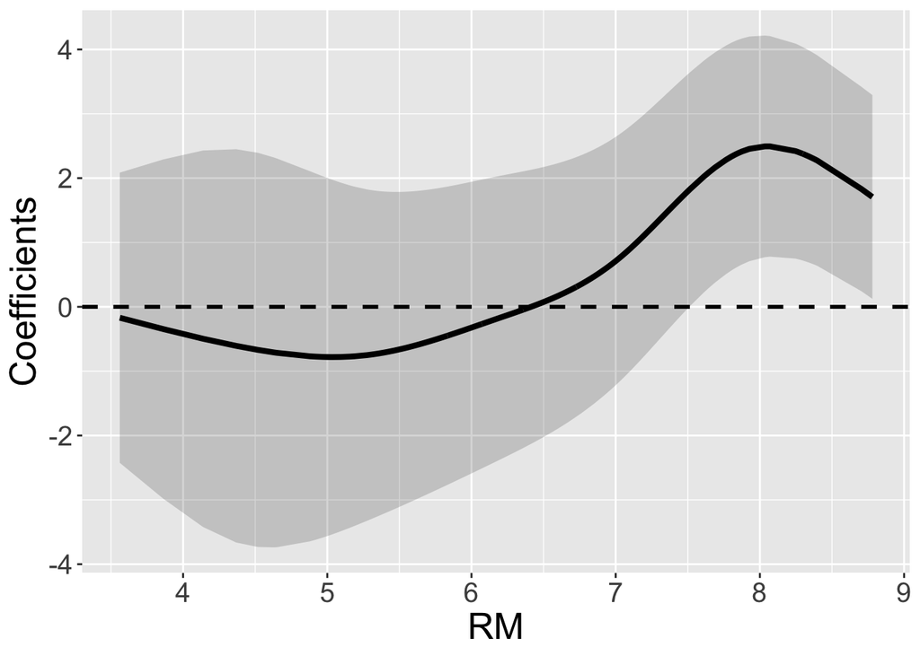

```r
plot_n(res,6)
```

The residual spatial process is plotted as

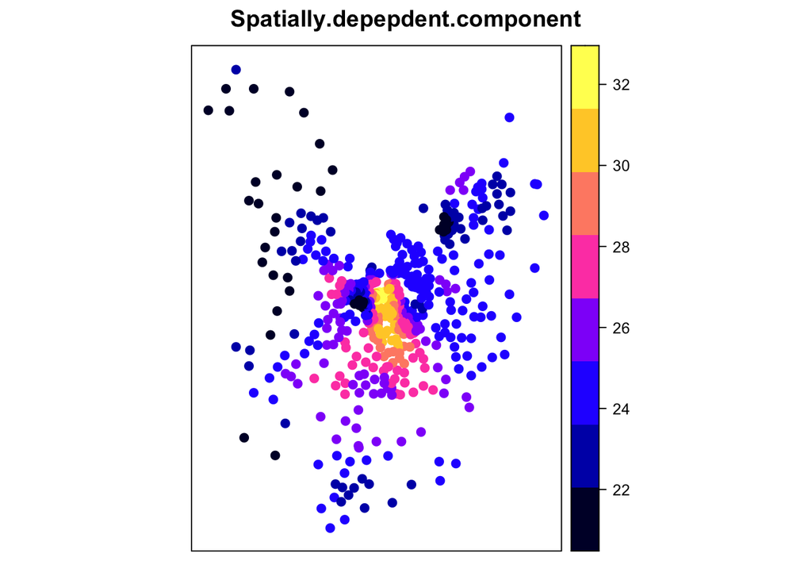

```r
plot_s(res)
```

```r
res   <- resf(y = y, x = x, meig = meig, nvc=TRUE, nvc_sel=1:3)
res
```

```
## Call:
## resf(y = y, x = x, nvc = TRUE, nvc_sel = 1:3, meig = meig)
##
## ----Non-spatially varying coefficients (summary)----
##
## Coefficients:
##    Intercept         CRIM               ZN               INDUS
##  Min.   :8.04   Min.   :-0.1978   Min.   :-0.02646   Min.   :-0.1618
##  1st Qu.:8.04   1st Qu.:-0.1978   1st Qu.: 0.02423   1st Qu.:-0.1618
##  Median :8.04   Median :-0.1978   Median : 0.02423   Median :-0.1618
##  Mean   :8.04   Mean   :-0.1978   Mean   : 0.02047   Mean   :-0.1618
##  3rd Qu.:8.04   3rd Qu.:-0.1978   3rd Qu.: 0.02423   3rd Qu.:-0.1618
##  Max.   :8.04   Max.   :-0.1978   Max.   : 0.07651   Max.   :-0.1618
##       CHAS             NOX               RM             AGE
##  Min.   :0.5596   Min.   :-32.04   Min.   :6.218   Min.   :-0.06464
##  1st Qu.:0.5596   1st Qu.:-32.04   1st Qu.:6.218   1st Qu.:-0.06464
##  Median :0.5596   Median :-32.04   Median :6.218   Median :-0.06464
##  Mean   :0.5596   Mean   :-32.04   Mean   :6.218   Mean   :-0.06464
##  3rd Qu.:0.5596   3rd Qu.:-32.04   3rd Qu.:6.218   3rd Qu.:-0.06464
##  Max.   :0.5596   Max.   :-32.04   Max.   :6.218   Max.   :-0.06464
##
## Statistical significance:
##                         Intercept CRIM  ZN INDUS CHAS NOX  RM AGE
## Not significant                 0    0 496     0  506   0   0   0
## Significant (10% level)         0    0   0     0    0   0   0   0
## Significant ( 5% level)       506    0   5   506    0   0   0   0
## Significant ( 1% level)         0  506   5     0    0 506 506 506
##
## ----Variance parameter------------------------
##
## Spatial effects (residuals):
##                      (Intercept)
## random_SE              6.6961726
## Moran.I/max(Moran.I)   0.6708208
##
## Non-spatially varying coefficients:
##                   CRIM          ZN        INDUS CHAS NOX RM AGE
## random_SE 2.947543e-08 0.008130433 2.735123e-07    0   0  0   0
##
## ----Error statistics--------------------------
##                      stat
## resid_SE        4.2790185
## adjR2(cond)     0.7797353
## rlogLik     -1537.6449527
## AIC          3103.2899053
## BIC          3162.4614187
```

## 3.2 Spatially varying coefficient modeling